# Home Alarm CLV

Prepare “Home Alarm, Inc.: Assessing Customer Lifetime Value” for class discussion and as an individual assignment and submit the assignment through GitLab. Be VERY clear about where results are coming from and what assumptions you are making in your R code. It is in your best interest that we do not have to struggle to figure out where your numbers came from. The assignment (pdf) is in the class Dropbox folder (week2/homealarm-ltv.pdf). Example R and Excel calculations are also on Dropbox (week1/readings).

## Setup

Create an rmarkdown document in which you calculate the CLV for a customers who uses auto-pay and for a customer that does not use auto-pay and answer question 1 through 4 in the assignment PDF.

## Analysis

The code chunk below sets the attrition notifications you should use in your analysis.

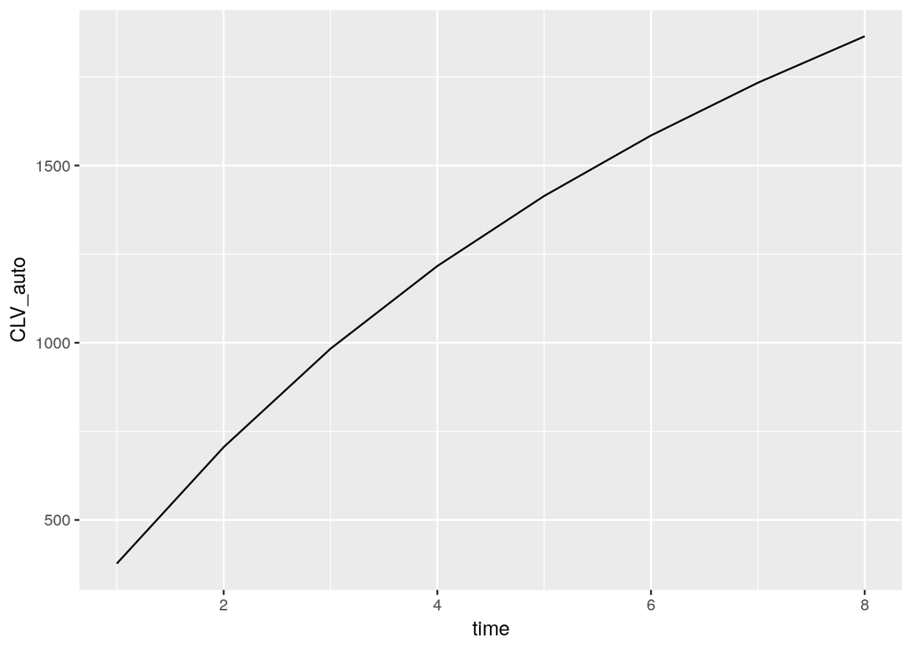

```r
## Attrition notifications
churn <- tibble::tibble(
  no_autopay = c(0,0.122, 0.162, 0.154, 0.134, 0.120,   0.111, 0.096),
  autopay =  c(0, 0.070, 0.097, 0.103, 0.095, 0.078, 0.069, 0.059),
  new_method =c(0,0, 0.097, 0.103, 0.095, 0.078, 0.069, 0.059)
)
residual_rate <- 1-churn
for (i in 2: length(residual_rate$autopay)){
  residual_rate$autopay[i]  = residual_rate$autopay[i]*residual_rate$autopay[i - 1]
}
for (i in 2: length(residual_rate$no_autopay)){
  residual_rate$no_autopay[i]  = residual_rate$no_autopay[i]*residual_rate$no_autopay[i - 1]
}
for (i in 2: length(residual_rate$new_method)){
  residual_rate$new_method[i]  = residual_rate$new_method[i]*residual_rate$new_method[i - 1]
}

annual_growth <- 0.03
annual_discount_rate <- 0.1
cost_service <- 0.15
marketing_cost <- 0.05
nr_years <- 8

time <- 1:nr_years
growth <- rep((1 + annual_growth)^(0:(nr_years-1)), each = 1)
revenues <- rep(480*(1+annual_growth), nr_years) * growth
service <- cost_service * revenues
marketing <- marketing_cost * revenues
profit <- revenues - service - marketing

active_auto <- residual_rate$autopay
exp_profit_auto <- active_auto * profit
#because the fee is paid monthly,so when discount ,using time -0.5
PV_exp_profit_auto <- exp_profit_auto / (1 + annual_discount_rate)^(time-0.5)
CLV_auto <- cumsum(PV_exp_profit_auto)
AWS_auto <- tibble::tibble(time, CLV_auto)
radiant.data::visualize(AWS_auto, xvar = "time", yvar = "CLV_auto", type = "line", custom = TRUE)
```

```r
print(AWS_auto)
```

```
# A tibble: 8 x 2
   time CLV_auto
  <int>    <dbl>
1     1     377.
2     2     706.
3     3     983.
4     4    1216.
5     5    1414.
6     6    1585.
7     7    1733.
8     8    1864.
```

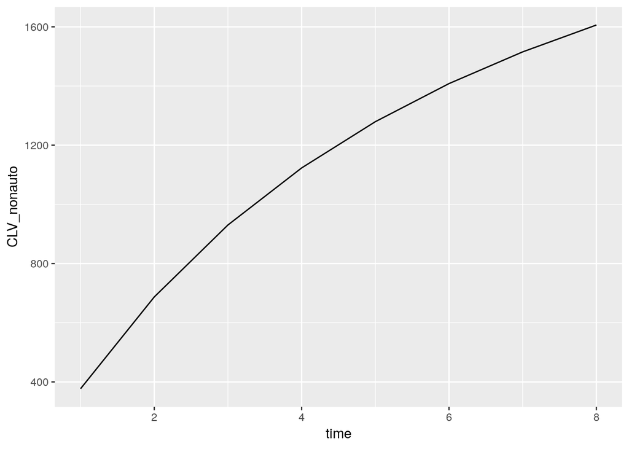

```r
active_nonauto <- residual_rate$no_autopay
exp_profit_nonauto <- active_nonauto * profit
PV_exp_profit_nonauto <- exp_profit_nonauto / (1 + annual_discount_rate)^(time-0.5)
CLV_nonauto <- cumsum(PV_exp_profit_nonauto)
AWS_nonauto <- tibble::tibble(time, CLV_nonauto)
radiant.data::visualize(AWS_nonauto, xvar = "time", yvar = "CLV_nonauto", type = "line", custom = TRUE)
```

```r
print(AWS_nonauto)
```

```
# A tibble: 8 x 2
   time CLV_nonauto
  <int>       <dbl>
1     1        377.
2     2        687.
3     3        930.
4     4       1123.
5     5       1279.
6     6       1408.
7     7       1515.
8     8       1606.
```

```r
active_new_method <- residual_rate$new_method
exp_profit_new_method <- active_new_method * profit
PV_exp_profit_new_method <- exp_profit_new_method / (1 + annual_discount_rate)^(time-0.5)
CLV_new_method <- cumsum(PV_exp_profit_new_method)
AWS_new_method <- tibble::tibble(time, CLV_new_method)
print(AWS_new_method)
```

```
# A tibble: 8 x 2
   time CLV_new_method
  <int>          <dbl>
1     1           377.
2     2           730.
3     3          1029.
4     4          1280.
5     5          1492.
6     6          1676.
7     7          1835.
8     8          1976.
```

So for nonauto,CLV is 1606.09(Question 2 ) and for auto,CLV is 1864.46(Question1) For question 3,the maximum amount Home Alarm should spend on incentives to convert an existing customer to auto-pay is 1864.46-1606.09 = 258.37

Action 3 :For any customer decide to change to auto-pay this year and remain in the alarm service system,customer can choose one of the last five year(5-9 year) in the contact in the future to enjoy one year free service.(It means that if the customer want to use the free service ,in the second third,fourth and fifth year he will still pay for the service .For validation,suppose the customer use the free service in fifth year ,after changing the churn rate ,final clv is bigger than 1606)

finish!

Please generate an HTML (Notebook) with your answers to all the questions listed in the homealarm-clv.pdf file on Dropbox. When you have finished editing the Rmarkdown document and generated the HTML report make sure to save, commit, and push it to GitLab. We will collect all the rmarkdown files from GitLab after the due date.